# Risk Factor Analysis

## Outcome Variable

**Outcome Variable:** whz

## Predictor Variables

**Intervention Variable:** feducyrs

**Adjustment Set:**

- arm
- W_mage
- meducyrs
- hhwealth_quart
- W_mhtcm
- single
- impsan
- W_gagebrth
- W_birthwt
- W_birthlen
- vagbrth
- parity
- delta_W_mage
- delta_meducyrs
- delta_hhwealth_quart
- delta_W_mhtcm
- delta_single
- delta_impsan
- delta_W_gagebrth
- delta_W_birthwt
- delta_W_birthlen
- delta_vagbrth
- delta_parity

## Stratifying Variables

The analysis was stratified on these variable(s):

- agecat
- studyid
- country

## Data Summary

| agecat | studyid | country | feducyrs | n_cell | n |
| --- | --- | --- | --- | --- | --- |
| 6 months | ki0047075b-MAL-ED | BANGLADESH | High | 50 | 132 |
| 6 months | ki0047075b-MAL-ED | BANGLADESH | Low | 36 | 132 |
| 6 months | ki0047075b-MAL-ED | BANGLADESH | Medium | 46 | 132 |
| 6 months | ki0047075b-MAL-ED | INDIA | High | 43 | 138 |
| 6 months | ki0047075b-MAL-ED | INDIA | Low | 54 | 138 |
| 6 months | ki0047075b-MAL-ED | INDIA | Medium | 41 | 138 |
| 6 months | ki0047075b-MAL-ED | NEPAL | High | 40 | 95 |
| 6 months | ki0047075b-MAL-ED | NEPAL | Low | 27 | 95 |
| 6 months | ki0047075b-MAL-ED | NEPAL | Medium | 28 | 95 |
| 6 months | ki0047075b-MAL-ED | PERU | High | 107 | 224 |
| 6 months | ki0047075b-MAL-ED | PERU | Low | 60 | 224 |
| 6 months | ki0047075b-MAL-ED | PERU | Medium | 57 | 224 |
| 6 months | ki0047075b-MAL-ED | SOUTH AFRICA | High | 33 | 92 |
| 6 months | ki0047075b-MAL-ED | SOUTH AFRICA | Low | 35 | 92 |
| 6 months | ki0047075b-MAL-ED | SOUTH AFRICA | Medium | 24 | 92 |
| 6 months | ki0047075b-MAL-ED | TANZANIA, UNITED REPUBLIC OF | High | 127 | 201 |
| 6 months | ki0047075b-MAL-ED | TANZANIA, UNITED REPUBLIC OF | Low | 55 | 201 |
| 6 months | ki0047075b-MAL-ED | TANZANIA, UNITED REPUBLIC OF | Medium | 19 | 201 |
| 6 months | ki1000304b-SAS-CompFeed | INDIA | High | 349 | 1331 |
| 6 months | ki1000304b-SAS-CompFeed | INDIA | Low | 548 | 1331 |
| 6 months | ki1000304b-SAS-CompFeed | INDIA | Medium | 434 | 1331 |
| 6 months | ki1000304b-SAS-FoodSuppl | INDIA | High | 101 | 380 |
| 6 months | ki1000304b-SAS-FoodSuppl | INDIA | Low | 132 | 380 |
| 6 months | ki1000304b-SAS-FoodSuppl | INDIA | Medium | 147 | 380 |
| 6 months | ki1017093b-PROVIDE | BANGLADESH | High | 203 | 582 |
| 6 months | ki1017093b-PROVIDE | BANGLADESH | Low | 200 | 582 |
| 6 months | ki1017093b-PROVIDE | BANGLADESH | Medium | 179 | 582 |
| 6 months | ki1017093c-NIH-Crypto | BANGLADESH | High | 279 | 715 |
| 6 months | ki1017093c-NIH-Crypto | BANGLADESH | Low | 223 | 715 |
| 6 months | ki1017093c-NIH-Crypto | BANGLADESH | Medium | 213 | 715 |

[output cut: 84 more lines]

The following strata were considered:

- agecat: 24 months, studyid: ki0047075b-MAL-ED, country: BANGLADESH
- agecat: 24 months, studyid: ki0047075b-MAL-ED, country: INDIA
- agecat: 24 months, studyid: ki0047075b-MAL-ED, country: NEPAL
- agecat: 24 months, studyid: ki0047075b-MAL-ED, country: PERU
- agecat: 24 months, studyid: ki0047075b-MAL-ED, country: SOUTH AFRICA
- agecat: 24 months, studyid: ki0047075b-MAL-ED, country: TANZANIA, UNITED REPUBLIC OF
- agecat: 24 months, studyid: ki1017093b-PROVIDE, country: BANGLADESH
- agecat: 24 months, studyid: ki1017093c-NIH-Crypto, country: BANGLADESH
- agecat: 24 months, studyid: ki1066203-TanzaniaChild2, country: TANZANIA, UNITED REPUBLIC OF
- agecat: 24 months, studyid: ki1113344-GMS-Nepal, country: NEPAL
- agecat: 24 months, studyid: ki1119695-PROBIT, country: BELARUS
- agecat: 24 months, studyid: ki1126311-ZVITAMBO, country: ZIMBABWE
- agecat: 24 months, studyid: ki1135781-COHORTS, country: GUATEMALA
- agecat: 24 months, studyid: ki1135781-COHORTS, country: INDIA
- agecat: 24 months, studyid: ki1135781-COHORTS, country: PHILIPPINES
- agecat: 24 months, studyid: ki1148112-LCNI-5, country: MALAWI
- agecat: 24 months, studyid: kiGH5241-JiVitA-3, country: BANGLADESH
- agecat: 24 months, studyid: kiGH5241-JiVitA-4, country: BANGLADESH
- agecat: 6 months, studyid: ki0047075b-MAL-ED, country: BANGLADESH
- agecat: 6 months, studyid: ki0047075b-MAL-ED, country: INDIA
- agecat: 6 months, studyid: ki0047075b-MAL-ED, country: NEPAL
- agecat: 6 months, studyid: ki0047075b-MAL-ED, country: PERU
- agecat: 6 months, studyid: ki0047075b-MAL-ED, country: SOUTH AFRICA
- agecat: 6 months, studyid: ki0047075b-MAL-ED, country: TANZANIA, UNITED REPUBLIC OF
- agecat: 6 months, studyid: ki1000304b-SAS-CompFeed, country: INDIA
- agecat: 6 months, studyid: ki1000304b-SAS-FoodSuppl, country: INDIA
- agecat: 6 months, studyid: ki1017093b-PROVIDE, country: BANGLADESH
- agecat: 6 months, studyid: ki1017093c-NIH-Crypto, country: BANGLADESH
- agecat: 6 months, studyid: ki1066203-TanzaniaChild2, country: TANZANIA, UNITED REPUBLIC OF
- agecat: 6 months, studyid: ki1113344-GMS-Nepal, country: NEPAL
- agecat: 6 months, studyid: ki1119695-PROBIT, country: BELARUS
- agecat: 6 months, studyid: ki1126311-ZVITAMBO, country: ZIMBABWE
- agecat: 6 months, studyid: ki1135781-COHORTS, country: GUATEMALA
- agecat: 6 months, studyid: ki1135781-COHORTS, country: INDIA
- agecat: 6 months, studyid: ki1135781-COHORTS, country: PHILIPPINES
- agecat: 6 months, studyid: ki1148112-LCNI-5, country: MALAWI
- agecat: 6 months, studyid: kiGH5241-JiVitA-3, country: BANGLADESH
- agecat: 6 months, studyid: kiGH5241-JiVitA-4, country: BANGLADESH

### Dropped Strata

Some strata were dropped due to rare outcomes:

- agecat: 24 months, studyid: ki1066203-TanzaniaChild2, country: TANZANIA, UNITED REPUBLIC OF

## Methods Detail

We’re interested in the causal parameters $E[Y_a]$ for all values of $a \in \mathcal{A}$. These parameters represent the mean outcome if, possibly contrary to fact, we intervened to set all units to have $A=a$. Under the randomization and positivity assumptions, these are identified by the statistical parameters $\psi_a=E_W[E_{Y|A,W}(Y|A=a,W)]$. In addition, we’re interested in the mean of $Y$, $E[Y]$ under no intervention (the observed mean). We will estimate these parameters by using SuperLearner to fit the relevant likelihood factors – $E_{Y|A,W}(Y|A=a,W)$ and $p(A=a|W)$, and then updating our likelihood fit using a joint TMLE.

For unadjusted analyses ($W=\{\}$), initial likelihoods were estimated using Lrnr_glm to estimate the simple $E(Y|A)$ and Lrnr_mean to estimate $p(A)$. For adjusted analyses, a small library containing Lrnr_glmnet, Lrnr_xgboost, and Lrnr_mean was used.

Having estimated these parameters, we will then use the delta method to estimate relative risks and attributable risks relative to a prespecified baseline level of $A$.

# Results Detail

## Results Plots

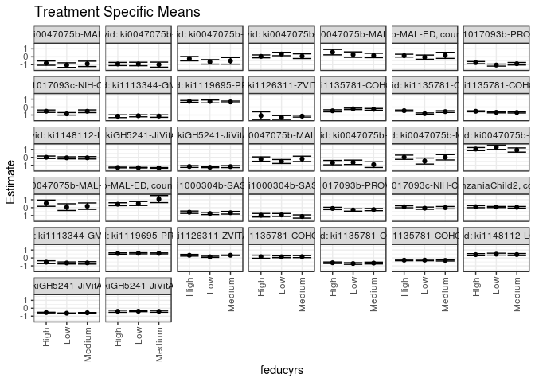

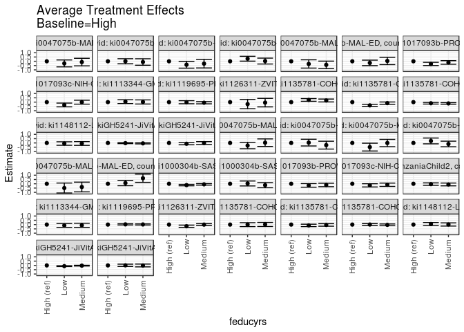

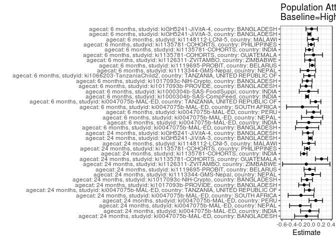

## Results Table

### Parameter: TSM

| agecat | studyid | country | intervention_level | baseline_level | estimate | ci_lower | ci_upper |
| --- | --- | --- | --- | --- | --- | --- | --- |
| 6 months | ki0047075b-MAL-ED | BANGLADESH | High | NA | -0.2174495 | -0.4950844 | 0.0601855 |
| 6 months | ki0047075b-MAL-ED | BANGLADESH | Low | NA | -0.5202380 | -0.7702833 | -0.2701927 |
| 6 months | ki0047075b-MAL-ED | BANGLADESH | Medium | NA | -0.1879361 | -0.5268829 | 0.1510107 |
| 6 months | ki0047075b-MAL-ED | INDIA | High | NA | -0.6629935 | -0.9417016 | -0.3842855 |
| 6 months | ki0047075b-MAL-ED | INDIA | Low | NA | -0.6245437 | -0.9008636 | -0.3482238 |
| 6 months | ki0047075b-MAL-ED | INDIA | Medium | NA | -0.9182906 | -1.2784809 | -0.5581002 |
| 6 months | ki0047075b-MAL-ED | NEPAL | High | NA | 0.0172374 | -0.2497834 | 0.2842581 |
| 6 months | ki0047075b-MAL-ED | NEPAL | Low | NA | -0.4669314 | -0.8497570 | -0.0841058 |
| 6 months | ki0047075b-MAL-ED | NEPAL | Medium | NA | 0.0092703 | -0.3253441 | 0.3438846 |
| 6 months | ki0047075b-MAL-ED | PERU | High | NA | 1.0425408 | 0.8503914 | 1.2346902 |
| 6 months | ki0047075b-MAL-ED | PERU | Low | NA | 1.2770669 | 0.9992029 | 1.5549308 |
| 6 months | ki0047075b-MAL-ED | PERU | Medium | NA | 0.9213565 | 0.6554496 | 1.1872634 |
| 6 months | ki0047075b-MAL-ED | SOUTH AFRICA | High | NA | 0.5657049 | 0.1728666 | 0.9585433 |
| 6 months | ki0047075b-MAL-ED | SOUTH AFRICA | Low | NA | 0.0691798 | -0.3571757 | 0.4955353 |
| 6 months | ki0047075b-MAL-ED | SOUTH AFRICA | Medium | NA | 0.1887845 | -0.2184964 | 0.5960654 |
| 6 months | ki0047075b-MAL-ED | TANZANIA, UNITED REPUBLIC OF | High | NA | 0.4370626 | 0.2526050 | 0.6215203 |
| 6 months | ki0047075b-MAL-ED | TANZANIA, UNITED REPUBLIC OF | Low | NA | 0.5225200 | 0.2698654 | 0.7751746 |
| 6 months | ki0047075b-MAL-ED | TANZANIA, UNITED REPUBLIC OF | Medium | NA | 1.0805723 | 0.6371261 | 1.5240184 |
| 6 months | ki1000304b-SAS-CompFeed | INDIA | High | NA | -0.5767403 | -0.7278093 | -0.4256714 |
| 6 months | ki1000304b-SAS-CompFeed | INDIA | Low | NA | -0.7331082 | -0.8747510 | -0.5914655 |
| 6 months | ki1000304b-SAS-CompFeed | INDIA | Medium | NA | -0.6443755 | -0.8114035 | -0.4773475 |
| 6 months | ki1000304b-SAS-FoodSuppl | INDIA | High | NA | -0.9565926 | -1.1797426 | -0.7334425 |
| 6 months | ki1000304b-SAS-FoodSuppl | INDIA | Low | NA | -0.9223236 | -1.1055901 | -0.7390571 |
| 6 months | ki1000304b-SAS-FoodSuppl | INDIA | Medium | NA | -1.1186390 | -1.3209467 | -0.9163313 |
| 6 months | ki1017093b-PROVIDE | BANGLADESH | High | NA | -0.0998517 | -0.2464909 | 0.0467874 |
| 6 months | ki1017093b-PROVIDE | BANGLADESH | Low | NA | -0.2896060 | -0.4397718 | -0.1394401 |
| 6 months | ki1017093b-PROVIDE | BANGLADESH | Medium | NA | -0.2400092 | -0.3800837 | -0.0999348 |
| 6 months | ki1017093c-NIH-Crypto | BANGLADESH | High | NA | 0.1148998 | -0.0097647 | 0.2395643 |
| 6 months | ki1017093c-NIH-Crypto | BANGLADESH | Low | NA | -0.0682086 | -0.2097532 | 0.0733360 |
| 6 months | ki1017093c-NIH-Crypto | BANGLADESH | Medium | NA | 0.0011096 | -0.1459099 | 0.1481292 |

[output cut: 81 more lines]

### Parameter: E(Y)

| agecat | studyid | country | intervention_level | baseline_level | estimate | ci_lower | ci_upper |
| --- | --- | --- | --- | --- | --- | --- | --- |
| 6 months | ki0047075b-MAL-ED | BANGLADESH | NA | NA | -0.3053662 | -0.4828374 | -0.1278949 |
| 6 months | ki0047075b-MAL-ED | INDIA | NA | NA | -0.7164734 | -0.8860809 | -0.5468660 |
| 6 months | ki0047075b-MAL-ED | NEPAL | NA | NA | 0.0313158 | -0.1673661 | 0.2299977 |
| 6 months | ki0047075b-MAL-ED | PERU | NA | NA | 1.0866741 | 0.9521834 | 1.2211648 |
| 6 months | ki0047075b-MAL-ED | SOUTH AFRICA | NA | NA | 0.3830435 | 0.1435272 | 0.6225598 |
| 6 months | ki0047075b-MAL-ED | TANZANIA, UNITED REPUBLIC OF | NA | NA | 0.5218823 | 0.3795317 | 0.6642328 |
| 6 months | ki1000304b-SAS-CompFeed | INDIA | NA | NA | -0.6641059 | -0.8040033 | -0.5242086 |
| 6 months | ki1000304b-SAS-FoodSuppl | INDIA | NA | NA | -1.0121579 | -1.1280429 | -0.8962729 |
| 6 months | ki1017093b-PROVIDE | BANGLADESH | NA | NA | -0.2083706 | -0.2927992 | -0.1239419 |
| 6 months | ki1017093c-NIH-Crypto | BANGLADESH | NA | NA | 0.0297622 | -0.0491685 | 0.1086930 |
| 6 months | ki1066203-TanzaniaChild2 | TANZANIA, UNITED REPUBLIC OF | NA | NA | 0.0791782 | 0.0263777 | 0.1319787 |
| 6 months | ki1113344-GMS-Nepal | NEPAL | NA | NA | -0.6041489 | -0.6904591 | -0.5178387 |
| 6 months | ki1119695-PROBIT | BELARUS | NA | NA | 0.5783110 | 0.5188487 | 0.6377732 |
| 6 months | ki1126311-ZVITAMBO | ZIMBABWE | NA | NA | 0.3096296 | 0.2832594 | 0.3359998 |
| 6 months | ki1135781-COHORTS | GUATEMALA | NA | NA | 0.1987403 | 0.1250477 | 0.2724329 |
| 6 months | ki1135781-COHORTS | INDIA | NA | NA | -0.6502599 | -0.7103477 | -0.5901722 |
| 6 months | ki1135781-COHORTS | PHILIPPINES | NA | NA | -0.2839930 | -0.3263706 | -0.2416154 |
| 6 months | ki1148112-LCNI-5 | MALAWI | NA | NA | 0.4414655 | 0.3698299 | 0.5131012 |
| 6 months | kiGH5241-JiVitA-3 | BANGLADESH | NA | NA | -0.5904964 | -0.6106039 | -0.5703890 |
| 6 months | kiGH5241-JiVitA-4 | BANGLADESH | NA | NA | -0.3829461 | -0.4315670 | -0.3343252 |
| 24 months | ki0047075b-MAL-ED | BANGLADESH | NA | NA | -0.9032479 | -1.0730238 | -0.7334719 |
| 24 months | ki0047075b-MAL-ED | INDIA | NA | NA | -0.9451515 | -1.0860650 | -0.8042380 |
| 24 months | ki0047075b-MAL-ED | NEPAL | NA | NA | -0.4668132 | -0.6466833 | -0.2869431 |
| 24 months | ki0047075b-MAL-ED | PERU | NA | NA | 0.1412500 | 0.0103684 | 0.2721316 |
| 24 months | ki0047075b-MAL-ED | SOUTH AFRICA | NA | NA | 0.3713736 | 0.1781064 | 0.5646408 |
| 24 months | ki0047075b-MAL-ED | TANZANIA, UNITED REPUBLIC OF | NA | NA | 0.1027966 | -0.0354562 | 0.2410495 |
| 24 months | ki1017093b-PROVIDE | BANGLADESH | NA | NA | -0.8879412 | -0.9708680 | -0.8050144 |
| 24 months | ki1017093c-NIH-Crypto | BANGLADESH | NA | NA | -0.6103502 | -0.7050157 | -0.5156847 |
| 24 months | ki1113344-GMS-Nepal | NEPAL | NA | NA | -1.1284909 | -1.2160945 | -1.0408874 |
| 24 months | ki1119695-PROBIT | BELARUS | NA | NA | 0.6836046 | 0.5719211 | 0.7952881 |
| 24 months | ki1126311-ZVITAMBO | ZIMBABWE | NA | NA | -1.1874750 | -1.2917540 | -1.0831960 |
| 24 months | ki1135781-COHORTS | GUATEMALA | NA | NA | -0.2662176 | -0.3220630 | -0.2103721 |
| 24 months | ki1135781-COHORTS | INDIA | NA | NA | -0.6051533 | -0.6581071 | -0.5521995 |
| 24 months | ki1135781-COHORTS | PHILIPPINES | NA | NA | -0.6155714 | -0.6532287 | -0.5779140 |
| 24 months | ki1148112-LCNI-5 | MALAWI | NA | NA | -0.0443964 | -0.1269881 | 0.0381953 |
| 24 months | kiGH5241-JiVitA-3 | BANGLADESH | NA | NA | -1.2984354 | -1.3225016 | -1.2743692 |
| 24 months | kiGH5241-JiVitA-4 | BANGLADESH | NA | NA | -1.2260902 | -1.2680212 | -1.1841592 |

### Parameter: ATE

| agecat | studyid | country | intervention_level | baseline_level | estimate | ci_lower | ci_upper |
| --- | --- | --- | --- | --- | --- | --- | --- |
| 6 months | ki0047075b-MAL-ED | BANGLADESH | High | High | 0.0000000 | 0.0000000 | 0.0000000 |
| 6 months | ki0047075b-MAL-ED | BANGLADESH | Low | High | -0.3027885 | -0.6766210 | 0.0710439 |
| 6 months | ki0047075b-MAL-ED | BANGLADESH | Medium | High | 0.0295134 | -0.4101760 | 0.4692028 |
| 6 months | ki0047075b-MAL-ED | INDIA | High | High | 0.0000000 | 0.0000000 | 0.0000000 |
| 6 months | ki0047075b-MAL-ED | INDIA | Low | High | 0.0384498 | -0.3540528 | 0.4309524 |
| 6 months | ki0047075b-MAL-ED | INDIA | Medium | High | -0.2552970 | -0.7120131 | 0.2014191 |
| 6 months | ki0047075b-MAL-ED | NEPAL | High | High | 0.0000000 | 0.0000000 | 0.0000000 |
| 6 months | ki0047075b-MAL-ED | NEPAL | Low | High | -0.4841688 | -0.9401693 | -0.0281683 |
| 6 months | ki0047075b-MAL-ED | NEPAL | Medium | High | -0.0079671 | -0.4334862 | 0.4175520 |
| 6 months | ki0047075b-MAL-ED | PERU | High | High | 0.0000000 | 0.0000000 | 0.0000000 |
| 6 months | ki0047075b-MAL-ED | PERU | Low | High | 0.2345260 | -0.1062192 | 0.5752713 |
| 6 months | ki0047075b-MAL-ED | PERU | Medium | High | -0.1211843 | -0.4478869 | 0.2055182 |
| 6 months | ki0047075b-MAL-ED | SOUTH AFRICA | High | High | 0.0000000 | 0.0000000 | 0.0000000 |
| 6 months | ki0047075b-MAL-ED | SOUTH AFRICA | Low | High | -0.4965251 | -1.0787842 | 0.0857339 |
| 6 months | ki0047075b-MAL-ED | SOUTH AFRICA | Medium | High | -0.3769204 | -0.9431789 | 0.1893380 |
| 6 months | ki0047075b-MAL-ED | TANZANIA, UNITED REPUBLIC OF | High | High | 0.0000000 | 0.0000000 | 0.0000000 |
| 6 months | ki0047075b-MAL-ED | TANZANIA, UNITED REPUBLIC OF | Low | High | 0.0854574 | -0.2282107 | 0.3991254 |
| 6 months | ki0047075b-MAL-ED | TANZANIA, UNITED REPUBLIC OF | Medium | High | 0.6435096 | 0.1630940 | 1.1239253 |
| 6 months | ki1000304b-SAS-CompFeed | INDIA | High | High | 0.0000000 | 0.0000000 | 0.0000000 |
| 6 months | ki1000304b-SAS-CompFeed | INDIA | Low | High | -0.1563679 | -0.2387521 | -0.0739837 |
| 6 months | ki1000304b-SAS-CompFeed | INDIA | Medium | High | -0.0676351 | -0.1586394 | 0.0233691 |
| 6 months | ki1000304b-SAS-FoodSuppl | INDIA | High | High | 0.0000000 | 0.0000000 | 0.0000000 |
| 6 months | ki1000304b-SAS-FoodSuppl | INDIA | Low | High | 0.0342689 | -0.2545115 | 0.3230494 |
| 6 months | ki1000304b-SAS-FoodSuppl | INDIA | Medium | High | -0.1620464 | -0.4633404 | 0.1392476 |
| 6 months | ki1017093b-PROVIDE | BANGLADESH | High | High | 0.0000000 | 0.0000000 | 0.0000000 |
| 6 months | ki1017093b-PROVIDE | BANGLADESH | Low | High | -0.1897542 | -0.3985319 | 0.0190235 |
| 6 months | ki1017093b-PROVIDE | BANGLADESH | Medium | High | -0.1401575 | -0.3423436 | 0.0620287 |
| 6 months | ki1017093c-NIH-Crypto | BANGLADESH | High | High | 0.0000000 | 0.0000000 | 0.0000000 |
| 6 months | ki1017093c-NIH-Crypto | BANGLADESH | Low | High | -0.1831084 | -0.3717021 | 0.0054853 |
| 6 months | ki1017093c-NIH-Crypto | BANGLADESH | Medium | High | -0.1137901 | -0.3066154 | 0.0790351 |

[output cut: 81 more lines]

### Parameter: PAR

| agecat | studyid | country | intervention_level | baseline_level | estimate | ci_lower | ci_upper |
| --- | --- | --- | --- | --- | --- | --- | --- |
| 6 months | ki0047075b-MAL-ED | BANGLADESH | High | NA | -0.0879167 | -0.3232470 | 0.1474136 |
| 6 months | ki0047075b-MAL-ED | INDIA | High | NA | -0.0534799 | -0.2985877 | 0.1916279 |
| 6 months | ki0047075b-MAL-ED | NEPAL | High | NA | 0.0140784 | -0.2019820 | 0.2301389 |
| 6 months | ki0047075b-MAL-ED | PERU | High | NA | 0.0441333 | -0.0990487 | 0.1873153 |
| 6 months | ki0047075b-MAL-ED | SOUTH AFRICA | High | NA | -0.1826615 | -0.5045227 | 0.1391998 |
| 6 months | ki0047075b-MAL-ED | TANZANIA, UNITED REPUBLIC OF | High | NA | 0.0848196 | -0.0233010 | 0.1929403 |
| 6 months | ki1000304b-SAS-CompFeed | INDIA | High | NA | -0.0873656 | -0.1179148 | -0.0568164 |
| 6 months | ki1000304b-SAS-FoodSuppl | INDIA | High | NA | -0.0555653 | -0.2479305 | 0.1367998 |
| 6 months | ki1017093b-PROVIDE | BANGLADESH | High | NA | -0.1085188 | -0.2246172 | 0.0075796 |
| 6 months | ki1017093c-NIH-Crypto | BANGLADESH | High | NA | -0.0851375 | -0.1853865 | 0.0151114 |
| 6 months | ki1066203-TanzaniaChild2 | TANZANIA, UNITED REPUBLIC OF | High | NA | -0.0437733 | -0.1564599 | 0.0689132 |
| 6 months | ki1113344-GMS-Nepal | NEPAL | High | NA | -0.0699701 | -0.2268973 | 0.0869570 |
| 6 months | ki1119695-PROBIT | BELARUS | High | NA | 0.0177888 | -0.0361577 | 0.0717352 |
| 6 months | ki1126311-ZVITAMBO | ZIMBABWE | High | NA | -0.0304736 | -0.1359229 | 0.0749757 |
| 6 months | ki1135781-COHORTS | GUATEMALA | High | NA | 0.0436661 | -0.1385686 | 0.2259008 |
| 6 months | ki1135781-COHORTS | INDIA | High | NA | -0.0431735 | -0.1176928 | 0.0313459 |
| 6 months | ki1135781-COHORTS | PHILIPPINES | High | NA | -0.0047309 | -0.0659344 | 0.0564726 |
| 6 months | ki1148112-LCNI-5 | MALAWI | High | NA | 0.0279712 | -0.0813912 | 0.1373336 |
| 6 months | kiGH5241-JiVitA-3 | BANGLADESH | High | NA | -0.0422047 | -0.0737765 | -0.0106330 |
| 6 months | kiGH5241-JiVitA-4 | BANGLADESH | High | NA | 0.0051666 | -0.1109398 | 0.1212731 |
| 24 months | ki0047075b-MAL-ED | BANGLADESH | High | NA | -0.1022292 | -0.3412285 | 0.1367702 |
| 24 months | ki0047075b-MAL-ED | INDIA | High | NA | -0.0339374 | -0.2205997 | 0.1527249 |
| 24 months | ki0047075b-MAL-ED | NEPAL | High | NA | -0.2273294 | -0.4436023 | -0.0110564 |
| 24 months | ki0047075b-MAL-ED | PERU | High | NA | 0.0886462 | -0.0491763 | 0.2264688 |
| 24 months | ki0047075b-MAL-ED | SOUTH AFRICA | High | NA | -0.2119783 | -0.4725585 | 0.0486018 |
| 24 months | ki0047075b-MAL-ED | TANZANIA, UNITED REPUBLIC OF | High | NA | -0.0423640 | -0.1428809 | 0.0581528 |
| 24 months | ki1017093b-PROVIDE | BANGLADESH | High | NA | -0.1481314 | -0.2582558 | -0.0380070 |
| 24 months | ki1017093c-NIH-Crypto | BANGLADESH | High | NA | -0.0902905 | -0.2034620 | 0.0228809 |
| 24 months | ki1113344-GMS-Nepal | NEPAL | High | NA | 0.0247414 | -0.1333343 | 0.1828170 |
| 24 months | ki1119695-PROBIT | BELARUS | High | NA | -0.0374095 | -0.1492690 | 0.0744499 |
| 24 months | ki1126311-ZVITAMBO | ZIMBABWE | High | NA | -0.1038204 | -0.5848815 | 0.3772407 |
| 24 months | ki1135781-COHORTS | GUATEMALA | High | NA | 0.2050527 | 0.0810623 | 0.3290431 |
| 24 months | ki1135781-COHORTS | INDIA | High | NA | -0.1541723 | -0.2195619 | -0.0887826 |
| 24 months | ki1135781-COHORTS | PHILIPPINES | High | NA | -0.0877537 | -0.1401187 | -0.0353888 |
| 24 months | ki1148112-LCNI-5 | MALAWI | High | NA | -0.0535761 | -0.1837464 | 0.0765942 |
| 24 months | kiGH5241-JiVitA-3 | BANGLADESH | High | NA | -0.0231894 | -0.0619341 | 0.0155553 |
| 24 months | kiGH5241-JiVitA-4 | BANGLADESH | High | NA | -0.0710956 | -0.1777917 | 0.0356006 |